# Yashpreet_yk8742_Individual Assignment #3

### Regression with ARIMA Errors Laboratory.

#### (Total 40 pts.)

#### Due: Dec. 2 (before midnight)

As a newly minted MSBA you start working for a large resort hotel managing 1,877 rooms. A tour operator that you freqently do business with has requested a block of 60 rooms for Aug. 22. As this operator will pay a discounted rate for each room, your manager is uncertain if she should give this block of rooms to the tour operator, and she has asked you to provide model-based support for this decision.

Although the price is discounted and it may prevent you from selling some of these rooms at the regular price, if you reject this request, any empty rooms will not generate any reveue and you would have incurred an opportunity cost by not selling these rooms.

After judicious consideration of the economic tradeoffs in the Newsvendor model, you and your manager determine that the block should be assigned to the tour operator only if the probability of your organic demand (excluding the room block in question) is smaller than 67% (i.e., you are on track to achieve a 67% service level).

To address the booking question you examine the following data set and proceed to develop a demand forecast model.

The data set **Booking Exercise.csv** consists of daily observations of the following six variables:

- **DATE**: Calendar date corresponding to each observation.
- **DOW**: Index (1-7) to indicate the day of the week each **DATE** corresponds to. This is redundant and it is eliminated below.
- **DEMAND**: Number of rooms actually sold on each **DATE**.
- **TUESDAY.BOOK**: Number of rooms booked on the Tuesday of the previous week for each day of the forthcoming week. This variable is used as an input to inform the forecasts of **DEMAND** for each day of the forthcoming week.
- **PICKUP.RATIO**: This is a calculated variable obtained as **PICKUP.RATIO = DEMAND/TUESDAY.BOOK** historically as **DEMAND** is observed. Because of this is a calculated relationship you can use either **PICKUP.RATIO** or **TUESDAY.BOOK** but you cannot use both variables simultaneously in a model to predict **DEMAND**.
- **DOW.INDEX**: This is a pre-calculated indicator of day-of-the-week demand intensity. This is obtained by the Hotel using information beyond what it is contained in this data set.

The code below reads the data set which includes up to the latest demand information (August 17) and prepares the data for the modeling process:

```r
library(fpp3)
library(tseries)
X <- read.csv("Booking Exercise.csv") %>%
  mutate(DATE = ymd(DATE)) %>%
  as_tsibble(index = DATE)


Fcst.X <- X %>% filter(DATE >= ymd("2010-08-18"))
X <- X %>% filter(DATE <= ymd("2010-08-17"))
```

1. (15 pt.) Fit (a) an ETS, (b) a plain ARIMA, (c) a linear regression model to predict **DEMAND** as a function of **TUESDAY.BOOK**, (c) a non-seasonal regression model with ARIMA errors using **TUESDAY.BOOK** and **DOW.INDEX** as explanatory variables, and (d) a seasonal regression model with ARIMA errors using only **TUESDAY.BOOK** as an explanatory variable. You may use automatic model selection to fit an initial model, but especially in cases (c) and (d) you should modify the automatically fitted models when appropriate.

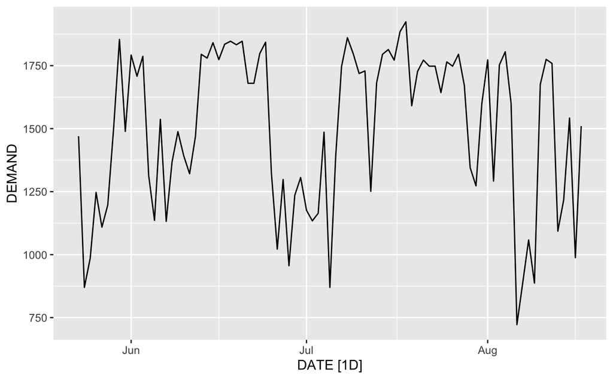

```r
X %>% autoplot(DEMAND)
```

```r
X %>% features(DEMAND, unitroot_ndiffs)
```

| ndiffs |
| --- |
| 0 |

```r
X %>% features(DEMAND, unitroot_nsdiffs)
```

| nsdiffs |
| --- |
| 0 |

```r
NA
```

From the plot and unit root tests above, we observe that demand is stationary and differencing is not required. So, D and d are 0.

```r
m <- X%>% model(ets = ETS(DEMAND),
                AR1 = ARIMA(DEMAND),
                lr = TSLM(DEMAND ~ TUESDAY.BOOK),
                AR2 = ARIMA(DEMAND ~ TUESDAY.BOOK + DOW.INDEX + PDQ(0, 0, 0)),
                AR3 = ARIMA(DEMAND ~ TUESDAY.BOOK))


m %>% report()
```

| .model | sigma2 | log_lik | AIC | AICc | BIC | MSE | AMSE | MAE | ar_roots | ma_roots | r_squared | adj_r_squared | statistic | p_value | df | CV | deviance | df.residual | rank |
| --- | --- | --- | --- | --- | --- | --- | --- | --- | --- | --- | --- | --- | --- | --- | --- | --- | --- | --- | --- |
| ets | 42400.128 | -653.0053 | 1326.0105 | 1328.9053 | 1350.6696 | 38013.91 | 74137.13 | 158.5357 |  |  | NA | NA | NA | NA | NA | NA | NA | NA | NA |
| AR1 | 47972.410 | -592.5331 | 1195.0662 | 1195.8070 | 1207.3958 | NA | NA | NA |  |  | NA | NA | NA | NA | NA | NA | NA | NA | NA |
| lr | 16097.552 | -543.7954 | 846.6954 | 846.9846 | 854.0931 | NA | NA | NA |  |  | 0.8375094 | 0.8355977 | 438.1072 | 2.714533e-35 | 2 | 16491.75 | 1368292 | 85 | 2 |
| AR2 | 8367.096 | -514.6720 | 1039.3439 | 1040.0847 | 1051.6735 | NA | NA | NA |  |  | NA | NA | NA | NA | NA | NA | NA | NA | NA |
| AR3 | 10091.556 | -481.5662 | 973.1324 | 973.9432 | 985.0425 | NA | NA | NA |  |  | NA | NA | NA | NA | NA | NA | NA | NA | NA |

```r
m %>% accuracy()
```

| .model | .type | ME | RMSE | MAE | MPE | MAPE | MASE | RMSSE | ACF1 |
| --- | --- | --- | --- | --- | --- | --- | --- | --- | --- |
| ets | Training | -4.986671e-01 | 194.97156 | 158.53566 | -1.3957409 | 11.738936 | 0.5140377 | 0.5107713 | 0.01229553 |
| AR1 | Training | 5.249625e+00 | 213.93172 | 162.52521 | -2.3575265 | 12.451828 | 0.5269735 | 0.5604417 | 0.08356669 |
| lr | Training | -1.300654e-15 | 125.40930 | 102.43574 | -1.0640899 | 7.604931 | 0.3321388 | 0.3285376 | 0.48724087 |
| AR2 | Training | -2.293549e-01 | 89.34429 | 72.15595 | -0.3360898 | 5.126424 | 0.2339592 | 0.2340572 | -0.05291793 |
| AR3 | Training | -2.856452e+00 | 93.89149 | 69.62993 | -0.5085148 | 4.920904 | 0.2257688 | 0.2459696 | -0.02812940 |

```r
NA
```

```r
m %>% select(ets) %>% report()
```

```
Series: DEMAND
Model: ETS(A,N,A)
  Smoothing parameters:
    alpha = 0.9998969
    gamma = 0.0001000471

  Initial states:
     l[0]      s[0]     s[-1]    s[-2]    s[-3]    s[-4]     s[-5]    s[-6]
 1465.946 -95.33474 -132.6443 95.16317 147.1579 87.43041 -210.9891 109.2166

  sigma^2:  42400.13

     AIC     AICc      BIC
1326.011 1328.905 1350.670
```

```r
m %>% select(AR1) %>% report()
```

```
Series: DEMAND
Model: ARIMA(1,0,0)(2,0,0)[7] w/ mean

Coefficients:
         ar1    sar1    sar2  constant
      0.7322  0.4746  0.2035   123.243
s.e.  0.0726  0.1086  0.1273    18.864

sigma^2 estimated as 47972:  log likelihood=-592.53
AIC=1195.07   AICc=1195.81   BIC=1207.4
```

```r
m %>% select(lr) %>% report()
```

```
Series: DEMAND
Model: TSLM

Residuals:
    Min      1Q  Median      3Q     Max
-296.95  -78.79   14.88   99.72  334.48

Coefficients:
              Estimate Std. Error t value Pr(>|t|)
(Intercept)  521.74996   48.84698   10.68   <2e-16 ***
TUESDAY.BOOK   0.69559    0.03323   20.93   <2e-16 ***
---
Signif. codes:  0 ‘***’ 0.001 ‘**’ 0.01 ‘*’ 0.05 ‘.’ 0.1 ‘ ’ 1

Residual standard error: 126.9 on 85 degrees of freedom
Multiple R-squared: 0.8375, Adjusted R-squared: 0.8356
F-statistic: 438.1 on 1 and 85 DF, p-value: < 2.22e-16
```

```r
m %>% select(AR2) %>% report()
```

```
Series: DEMAND
Model: LM w/ ARIMA(0,0,1) errors

Coefficients:
         ma1  TUESDAY.BOOK  DOW.INDEX  intercept
      0.7277        0.8030   824.6440  -450.9306
s.e.  0.0977        0.0318   171.1727   195.1647

sigma^2 estimated as 8367:  log likelihood=-514.67
AIC=1039.34   AICc=1040.08   BIC=1051.67
```

```r
m %>% select(AR3) %>% report()
```

```
Series: DEMAND
Model: LM w/ ARIMA(0,0,1)(2,1,0)[7] errors

Coefficients:
         ma1     sar1     sar2  TUESDAY.BOOK
      0.6541  -0.5251  -0.2240        0.7140
s.e.  0.1122   0.1122   0.1208        0.0363

sigma^2 estimated as 10092:  log likelihood=-481.57
AIC=973.13   AICc=973.94   BIC=985.04
```

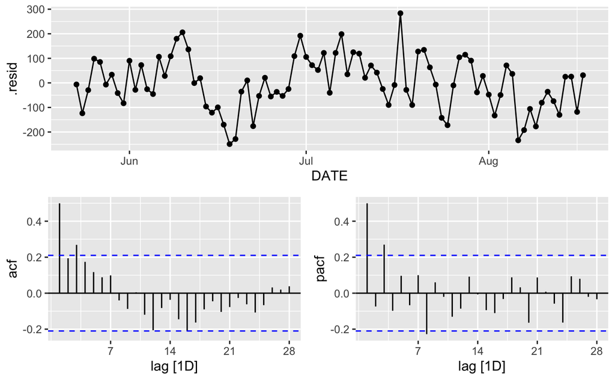

```r
m %>% select(AR2) %>%  residuals(type="regression") %>%
  gg_tsdisplay(.resid, "partial", lag_max = 28)
```

On the basis of these graphs, we can try following non seasonal ARIMA error models:

1. (0, 0, 1)
2. (1, 0, 0)
3. (1, 0, 1)
4. (3, 0, 3)

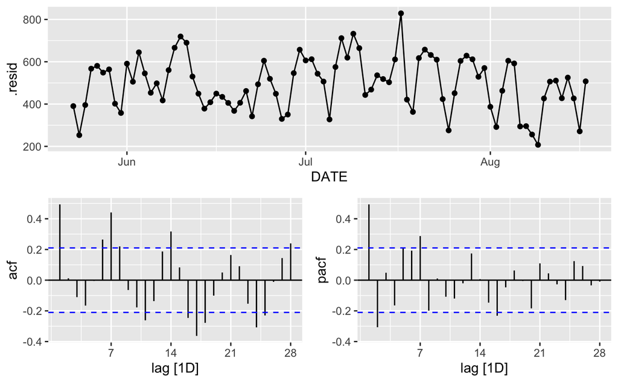

```r
m %>% select(AR3) %>%  residuals(type="regression") %>%
  gg_tsdisplay(.resid, "partial", lag_max = 28)
```

The possible suggestion for linear regression with seasonal ARIMA error are -

(0, 0, 1)(1, 0, 0)

(2, 0, 0)(1, 0, 0)

(2, 0, 1)(1, 0, 0)

(0, 0, 1)(1, 1, 0)

Since the auto model gives seasonal difference with 1 as the best model, we will try seasonal differencing as well.

```r
m <- X%>% model(ets = ETS(DEMAND),
                arima1 = ARIMA(DEMAND),
                lr = TSLM(DEMAND ~ TUESDAY.BOOK),
                AR20 = ARIMA(DEMAND ~ TUESDAY.BOOK + DOW.INDEX + pdq(0, 0, 1) + PDQ(0, 0, 0)),
                AR21 = ARIMA(DEMAND ~ TUESDAY.BOOK + DOW.INDEX + pdq(1, 0, 0) + PDQ(0, 0, 0)),
                AR22 = ARIMA(DEMAND ~ TUESDAY.BOOK + DOW.INDEX + pdq(1, 0, 1) + PDQ(0, 0, 0)),
                AR23 = ARIMA(DEMAND ~ TUESDAY.BOOK + DOW.INDEX + pdq(3, 0, 3) + PDQ(0, 0, 0)),
                AR30 = ARIMA(DEMAND ~ TUESDAY.BOOK + pdq(0, 0, 1) + PDQ(1, 0, 0)),
                AR31 = ARIMA(DEMAND ~ TUESDAY.BOOK + pdq(2, 0, 0) + PDQ(1, 0, 0)),
                AR32 = ARIMA(DEMAND ~ TUESDAY.BOOK + pdq(2, 0, 1) + PDQ(1, 0, 0)),
                AR33 = ARIMA(DEMAND ~ TUESDAY.BOOK + pdq(0, 0, 1) + PDQ(1, 1, 0))
                )

m %>% report()
```

| .model | sigma2 | log_lik | AIC | AICc | BIC | MSE | AMSE | MAE | ar_roots | ma_roots | r_squared | adj_r_squared | statistic | p_value | df | CV | deviance | df.residual | rank |
| --- | --- | --- | --- | --- | --- | --- | --- | --- | --- | --- | --- | --- | --- | --- | --- | --- | --- | --- | --- |
| ets | 42400.128 | -653.0053 | 1326.0105 | 1328.9053 | 1350.6696 | 38013.91 | 74137.13 | 158.5357 |  |  | NA | NA | NA | NA | NA | NA | NA | NA | NA |
| arima1 | 47972.410 | -592.5331 | 1195.0662 | 1195.8070 | 1207.3958 | NA | NA | NA |  |  | NA | NA | NA | NA | NA | NA | NA | NA | NA |
| lr | 16097.552 | -543.7954 | 846.6954 | 846.9846 | 854.0931 | NA | NA | NA |  |  | 0.8375094 | 0.8355977 | 438.1072 | 2.714533e-35 | 2 | 16491.75 | 1368292 | 85 | 2 |
| AR20 | 8367.096 | -514.6720 | 1039.3439 | 1040.0847 | 1051.6735 | NA | NA | NA |  |  | NA | NA | NA | NA | NA | NA | NA | NA | NA |
| AR21 | 9086.832 | -518.0249 | 1046.0499 | 1046.7906 | 1058.3794 | NA | NA | NA |  |  | NA | NA | NA | NA | NA | NA | NA | NA | NA |
| AR22 | 8372.783 | -514.2154 | 1040.4307 | 1041.4807 | 1055.2262 | NA | NA | NA |  |  | NA | NA | NA | NA | NA | NA | NA | NA | NA |
| AR23 | 8873.515 | -515.3546 | 1048.7091 | 1051.0468 | 1070.9023 | NA | NA | NA |  |  | NA | NA | NA | NA | NA | NA | NA | NA | NA |
| AR30 | 9041.412 | -518.5983 | 1047.1966 | 1047.9374 | 1059.5262 | NA | NA | NA |  |  | NA | NA | NA | NA | NA | NA | NA | NA | NA |
| AR31 | 9751.093 | -521.1876 | 1054.3752 | 1055.4252 | 1069.1706 | NA | NA | NA |  |  | NA | NA | NA | NA | NA | NA | NA | NA | NA |
| AR32 | 9150.366 | -518.1684 | 1050.3368 | 1051.7546 | 1067.5982 | NA | NA | NA |  |  | NA | NA | NA | NA | NA | NA | NA | NA | NA |

[output cut: 1 more lines]

Since one of the model (auto linear regression with seasonal ARIMA errors) involves differencing, we need to look at the RMSE to identify which model performs better.

```r
m %>% accuracy()
```

| .model | .type | ME | RMSE | MAE | MPE | MAPE | MASE | RMSSE | ACF1 |
| --- | --- | --- | --- | --- | --- | --- | --- | --- | --- |
| ets | Training | -4.986671e-01 | 194.97156 | 158.53566 | -1.3957409 | 11.738936 | 0.5140377 | 0.5107713 | 0.012295530 |
| arima1 | Training | 5.249625e+00 | 213.93172 | 162.52521 | -2.3575265 | 12.451828 | 0.5269735 | 0.5604417 | 0.083566689 |
| lr | Training | -1.300654e-15 | 125.40930 | 102.43574 | -1.0640899 | 7.604931 | 0.3321388 | 0.3285376 | 0.487240866 |
| AR20 | Training | -2.293549e-01 | 89.34429 | 72.15595 | -0.3360898 | 5.126424 | 0.2339592 | 0.2340572 | -0.052917934 |
| AR21 | Training | 1.324208e-02 | 93.10772 | 75.49237 | -0.4366850 | 5.335649 | 0.2447773 | 0.2439164 | 0.042006916 |
| AR22 | Training | -1.792131e-01 | 88.83461 | 71.93689 | -0.3931883 | 5.154242 | 0.2332489 | 0.2327220 | 0.029825380 |
| AR23 | Training | -2.435507e+00 | 89.76391 | 73.07396 | -0.7134457 | 5.307302 | 0.2369358 | 0.2351565 | 0.011014695 |
| AR30 | Training | 6.490107e-01 | 92.87472 | 75.04450 | -0.4069834 | 5.381430 | 0.2433251 | 0.2433060 | -0.026679603 |
| AR31 | Training | 4.416400e-01 | 95.86806 | 77.32473 | -0.5281876 | 5.585581 | 0.2507185 | 0.2511477 | 0.028477489 |
| AR32 | Training | 8.786860e-01 | 92.30009 | 75.18892 | -0.4152478 | 5.404109 | 0.2437934 | 0.2418006 | 0.005586116 |

[output cut: 1 more lines]

```r
NA
```

4. Linear regression with Non-seasonal ARIMA errors

5. Linear regression with Seasonal ARIMA errors

AR32 (2, 0, 1)(1, 0, 0) model gives us the best RMSE values among all seasonal models.

```r
m <- X%>% model(ets = ETS(DEMAND),
                AR1 = ARIMA(DEMAND ~ pdq(1,0,0) + PDQ(2,0,0)),
                lr = TSLM(DEMAND ~ TUESDAY.BOOK),
                AR2 = ARIMA(DEMAND ~ TUESDAY.BOOK + DOW.INDEX + pdq(1,0,0) + PDQ(0, 0, 0)),
                AR3 = ARIMA(DEMAND ~ TUESDAY.BOOK + pdq(2,0,1) + PDQ(1, 0, 0)))
```

```r
m %>% report()
```

| .model | sigma2 | log_lik | AIC | AICc | BIC | MSE | AMSE | MAE | ar_roots | ma_roots | r_squared | adj_r_squared | statistic | p_value | df | CV | deviance | df.residual | rank |
| --- | --- | --- | --- | --- | --- | --- | --- | --- | --- | --- | --- | --- | --- | --- | --- | --- | --- | --- | --- |
| ets | 42400.128 | -653.0053 | 1326.0105 | 1328.9053 | 1350.6696 | 38013.91 | 74137.13 | 158.5357 |  |  | NA | NA | NA | NA | NA | NA | NA | NA | NA |
| AR1 | 47972.410 | -592.5331 | 1195.0662 | 1195.8070 | 1207.3958 | NA | NA | NA |  |  | NA | NA | NA | NA | NA | NA | NA | NA | NA |
| lr | 16097.552 | -543.7954 | 846.6954 | 846.9846 | 854.0931 | NA | NA | NA |  |  | 0.8375094 | 0.8355977 | 438.1072 | 2.714533e-35 | 2 | 16491.75 | 1368292 | 85 | 2 |
| AR2 | 9086.832 | -518.0249 | 1046.0499 | 1046.7906 | 1058.3794 | NA | NA | NA |  |  | NA | NA | NA | NA | NA | NA | NA | NA | NA |
| AR3 | 9150.366 | -518.1684 | 1050.3368 | 1051.7546 | 1067.5982 | NA | NA | NA |  |  | NA | NA | NA | NA | NA | NA | NA | NA | NA |

```r
m %>% accuracy
```

| .model | .type | ME | RMSE | MAE | MPE | MAPE | MASE | RMSSE | ACF1 |
| --- | --- | --- | --- | --- | --- | --- | --- | --- | --- |
| ets | Training | -4.986671e-01 | 194.97156 | 158.53566 | -1.3957409 | 11.738936 | 0.5140377 | 0.5107713 | 0.012295530 |
| AR1 | Training | 5.249625e+00 | 213.93172 | 162.52521 | -2.3575265 | 12.451828 | 0.5269735 | 0.5604417 | 0.083566689 |
| lr | Training | -1.300654e-15 | 125.40930 | 102.43574 | -1.0640899 | 7.604931 | 0.3321388 | 0.3285376 | 0.487240866 |
| AR2 | Training | 1.324208e-02 | 93.10772 | 75.49237 | -0.4366850 | 5.335649 | 0.2447773 | 0.2439164 | 0.042006916 |
| AR3 | Training | 8.786860e-01 | 92.30009 | 75.18892 | -0.4152478 | 5.404109 | 0.2437934 | 0.2418006 | 0.005586116 |

```r
NA
```

2. (5 pt.) Which of the models are valid?

We look at the residuals of the ARIMA errors for model validity and check whether the errors are stationary and look like white noise or not.

```r
m %>%
  augment() %>%
  features(.resid, ljung_box, lag = 28)
```

| .model | lb_stat | lb_pvalue |
| --- | --- | --- |
| AR1 | 12.87727 | 0.9934310 |
| AR2 | 27.49174 | 0.4916086 |
| AR3 | 26.62260 | 0.5388625 |
| ets | 29.32897 | 0.3959871 |
| lr | 146.77022 | 0.0000000 |

All the models are valid except the plain Linear regression model since its p-value is 0.

3. (5 pt.) Using the information criteria (AICc and BIC) what is the best model?

After excluding linear regression model, arima2 - Linear regression with TUESDAY.BOOK & DOW.INDEX variables and AR(1) error has the lowest AICc and BIC. So, it is the best model.

4. (5 pt.) Use the **Fcst.X** data set created above to produce a demand forecast for the forthcoming week (i.e., Aug, 18 - 24) showing the default 80% and 90% confidence intervals.

```r
fcst = m %>% select(AR2) %>% forecast(new_data=Fcst.X)


fcst %>% hilo(level=c(80, 90))  %>%
  unpack_hilo(c('80%', '90%'))
```

| .model | DATE | DEMAND | .mean | DOW | TUESDAY.BOOK | PICKUP.RATIO | DOW.INDEX | 80%_lower | 80%_upper | 90%_lower | 90%_upper |
| --- | --- | --- | --- | --- | --- | --- | --- | --- | --- | --- | --- |
| AR2 | 2010-08-18 |  | 1730.841 | 4 | 1657 | NA | 1.0125249 | 1608.677 | 1853.004 | 1574.045 | 1887.636 |
| AR2 | 2010-08-19 |  | 1758.496 | 5 | 1643 | NA | 1.0678813 | 1622.194 | 1894.799 | 1583.554 | 1933.438 |
| AR2 | 2010-08-20 |  | 1383.357 | 6 | 1124 | NA | 1.1227265 | 1243.810 | 1522.903 | 1204.251 | 1562.462 |
| AR2 | 2010-08-21 |  | 1278.037 | 7 | 1074 | NA | 1.0486263 | 1137.708 | 1418.367 | 1097.927 | 1458.148 |
| AR2 | 2010-08-22 |  | 1736.349 | 1 | 1839 | NA | 0.8647725 | 1595.829 | 1876.869 | 1555.993 | 1916.705 |
| AR2 | 2010-08-23 |  | 1793.363 | 2 | 1862 | NA | 0.9105852 | 1652.796 | 1933.930 | 1612.947 | 1973.779 |
| AR2 | 2010-08-24 |  | 1865.461 | 3 | 1886 | NA | 0.9728832 | 1724.882 | 2006.039 | 1685.030 | 2045.891 |

```r
NA
```

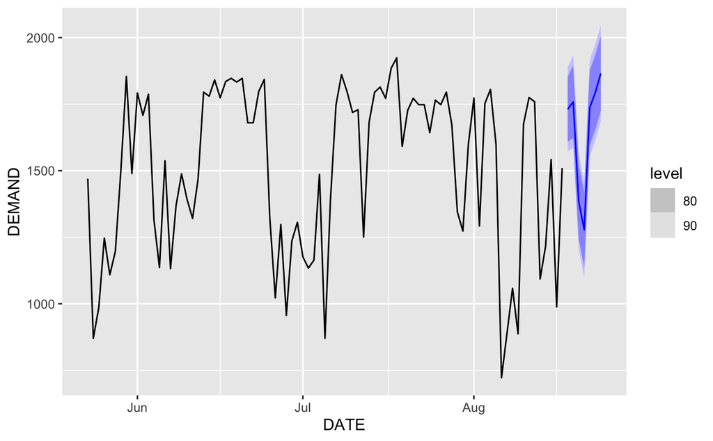

```r
fcst %>% autoplot(level=c(80, 90)) + geom_line(X, mapping = aes(y = DEMAND))
```

5. (10 pt.) What is your recommendation for your manager regarding the tour operator block? Should your manager sell the block of 60 rooms at a discounted price? Justify your answer.

We will start with maintaining 67% serviceability that is based on the capacity.

```r
service_level = (1877 - 60)
service_level
```

```
[1] 1817
```

We will calculate 33% confidence interval, to get 67th percentile for 22-24th August.

```r
fcst %>% hilo(level=c(33))  %>%
  unpack_hilo(c("33%")) %>% select(DATE, .mean, "33%_lower", "33%_upper") %>% filter(DATE >= "2010-08-22")
```

| DATE | .mean | 33%_lower | 33%_upper |
| --- | --- | --- | --- |
| 2010-08-22 | 1736.349 | 1689.622 | 1783.075 |
| 2010-08-23 | 1793.363 | 1746.621 | 1840.105 |
| 2010-08-24 | 1865.461 | 1818.715 | 1912.206 |